{% raw %}

#### Introduction

[Jupyter](http://jupyter.org/) has a beautiful notebook that lets you write and execute code, analyze data, embed content, and share reproducible work. Jupyter Notebook (previously referred to as IPython Notebook) allows you to easily share your code, data, plots, and explanation in a sinle notebook. Publishing is flexible: PDF, HTML, ipynb, dashboards, slides, and more. Code cells are based on an input and output format. For example:

```python
print "hello world"
```

```
hello world
```

#### Installation

There are a few ways to use a Jupyter Notebook:

- Install with [`pip`](https://pypi.python.org/pypi/pip). Open a terminal and type: `$ pip install ipython`.
- Windows users can install with [`setuptools`](http://ipython.org/ipython-doc/2/install/install.html#windows).
- [Anaconda](https://store.continuum.io/cshop/anaconda/) and [Enthought](https://store.enthought.com/downloads/#default) allow you to download a desktop version of Jupyter Notebook.
- [nteract](https://nteract.io/) allows users to work in a notebook enviornment via a desktop application.
- [Microsoft Azure](https://notebooks.azure.com/) provides hosted access to Jupyter Notebooks.
- [Domino Data Lab](http://support.dominodatalab.com/hc/en-us/articles/204856585-Jupyter-Notebooks) offers web-based Notebooks.
- tmpnb launches a temporary online Notebook for individual users.

#### Getting Started

Once you've installed the Notebook, you start from your terminal by calling `$ jupyter notebook`. This will open a browser on a [localhost](https://en.wikipedia.org/wiki/Localhost) to the URL of your Notebooks, by default http://127.0.0.1:8888. Windows users need to open up their Command Prompt. You'll see a dashboard with all your Notebooks. You can launch your Notebooks from there. The Notebook has the advantage of looking the same when you're coding and publishing. You just have all the options to move code, run cells, change kernels, and [use Markdown](https://github.com/adam-p/markdown-here/wiki/Markdown-Cheatsheet) when you're running a NB. Here's what a Notebook looks like in action if you call it from your terminal.

[figure not shown]

#### Helpful Commands

**- Tab Completion:** Jupyter supports tab completion! You can type `object_name.<TAB>` to view an object’s attributes. For tips on cell magics, running Notebooks, and exploring objects, check out the [Jupyter docs](https://ipython.org/ipython-doc/dev/interactive/tutorial.html#introducing-ipython).  
**- Help:** provides an introduction and overview of features.

```python
help
```

```
Type help() for interactive help, or help(object) for help about object.
```

**- Quick Reference:** open quick reference by running:

```python
quickref
```

**- Keyboard Shortcuts:** `Shift-Enter` will run a cell, `Ctrl-Enter` will run a cell in-place, `Alt-Enter` will run a cell and insert another below. See more shortcuts [here](https://ipython.org/ipython-doc/1/interactive/notebook.html#keyboard-shortcuts).

#### Package Management

When installing packages in IPython, you either need to install the package in your actual shell, or run the `!` prefix, e.g.:

```
!pip install packagename
```

You may want to [reload submodules](http://stackoverflow.com/questions/5364050/reloading-submodules-in-ipython) if you've edited the code in one. IPython comes with automatic reloading magic. You can reload all changed modules before executing a new line.

```
%load_ext autoreload
%autoreload 2
```

Some useful packages include:

- [Pandas](https://plot.ly/pandas/): import data via a url and create a dataframe to easily handle data for analysis and graphing. See examples of using Pandas here: https://plot.ly/pandas/.
- [NumPy](https://plot.ly/numpy/): a package for scientific computing with tools for algebra, random number generation, integrating with databases, and managing data. See examples of using NumPy here: https://plot.ly/numpy/.
- [SciPy](http://www.scipy.org/): a Python-based ecosystem of packages for math, science, and engineering.
- [Plotly](https://plot.ly/python/getting-started): a graphing library for making interactive, publication-quality graphs. See examples of statistic, scientific, 3D charts, and more here: https://plot.ly/python.

```python
import pandas as pd
import numpy as np
import scipy as sp
import plotly.plotly as py
```

#### Import Data

You can use pandas `read_csv()` function to import data. In the example below, we import a csv [hosted on github](https://github.com/plotly/datasets/) and plot it in a [table](https://plot.ly/python/table/) using Plotly:

```python
import plotly.plotly as py
import plotly.figure_factory as ff
import pandas as pd

df = pd.read_csv("https://raw.githubusercontent.com/plotly/datasets/master/school_earnings.csv")

table = ff.create_table(df)
py.iplot(table)
```

[interactive chart not shown]

Use `dataframe.column_title` to index the dataframe:

```python
schools = df.School
schools[0]
```

```
'MIT'
```

Most pandas functions also work on an entire dataframe. For example, calling `std()` calculates the standard deviation for each column.

```python
df.std()
```

```
Women    12.813683
Men      25.705289
gap      14.137084
dtype: float64
```

#### Plotting Inline

You can use [Plotly's python API](https://plot.ly/python) to plot inside your Jupyter Notebook by calling `plotly.plotly.iplot()` or `plotly.offline.iplot()` if working offline. Plotting in the notebook gives you the advantage of keeping your data analysis and plots in one place.

```python
import plotly.plotly as py
import plotly.tools as tls
from plotly.graph_objs import *
```

```python
py.iplot_mpl(fig1, strip_style = True, filename='ipython/mpl_example')
```

[interactive chart not shown]

#### Plotting Interactive Maps

```python
# Learn about API authentication here: https://plot.ly/python/getting-started
# Find your api_key here: https://plot.ly/settings/api

import plotly.plotly as py

df = pd.read_csv('https://plot.ly/~Dreamshot/5718/electoral-college-votes-by-us-state/.csv')

for col in df.columns:
    df[col] = df[col].astype(str)
```

```python
df.head()
```

|  | y | Source: <a href="https://en.wikipedia.org/wiki/Electoral_College_%28United_States%29">Wikipedia</a> |
| --- | --- | --- |
| 0 | DE | 3 |
| 1 | VT | 3 |
| 2 | ND | 3 |
| 3 | SD | 3 |
| 4 | MT | 3 |

```python
df.columns = ["state", "votes"]  # change column names
```

```python
df.head(1)
```

|  | state | votes |
| --- | --- | --- |
| 0 | DE | 3 |

Now we can make an interactive D3.js graph directly from pandas. See the [pandas maps](https://plot.ly/pandas/#maps) documentation to learn more.

```python
scl = [[0.0, 'rgb(242,240,247)'],[0.2, 'rgb(218,218,235)'],[0.4, 'rgb(188,189,220)'],\
            [0.6, 'rgb(158,154,200)'],[0.8, 'rgb(117,107,177)'],[1.0, 'rgb(84,39,143)']]

df['text'] = df['state']

data = [dict(
    type='choropleth',
    colorscale = scl,
    autocolorscale = False,
    locations = df['state'],
    z = df['votes'].astype(float),
    locationmode = 'USA-states',
    text = df['text'],
    hoverinfo = 'location+z',
    marker = dict(
        line = dict (
            color = 'rgb(255,255,255)',
            width = 2
        )
    ),
    colorbar = dict(
        title = "Votes"
    )
)]

layout = dict(
    title = '2016 Electoral College Votes<br>(Hover for breakdown)',
    geo = dict(
        scope='usa',
        projection=dict( type='albers usa' ),
        showlakes = True,
        lakecolor = 'rgb(255, 255, 255)'
    )
)

fig = dict(data=data, layout=layout)

py.iplot(fig, validate=False, filename='d3-electoral-map')
```

[interactive chart not shown]

#### 3D Plotting

Using Numpy and Plotly, we can make interactive [3D plots](https://plot.ly/python/#3d) in the Notebook as well.

```python
import plotly.plotly as py
from plotly.graph_objs import *

import numpy as np

s = np.linspace(0, 2 * np.pi, 240)
t = np.linspace(0, np.pi, 240)
tGrid, sGrid = np.meshgrid(s, t)

r = 2 + np.sin(7 * sGrid + 5 * tGrid)  # r = 2 + sin(7s+5t)
x = r * np.cos(sGrid) * np.sin(tGrid)  # x = r*cos(s)*sin(t)
y = r * np.sin(sGrid) * np.sin(tGrid)  # y = r*sin(s)*sin(t)
z = r * np.cos(tGrid)                  # z = r*cos(t)

surface = Surface(x=x, y=y, z=z)
data = Data([surface])

layout = Layout(
    title='Parametric Plot',
    scene=Scene(
        xaxis=XAxis(
            gridcolor='rgb(255, 255, 255)',
            zerolinecolor='rgb(255, 255, 255)',
            showbackground=True,
            backgroundcolor='rgb(230, 230,230)'
        ),
        yaxis=YAxis(
            gridcolor='rgb(255, 255, 255)',
            zerolinecolor='rgb(255, 255, 255)',
            showbackground=True,
            backgroundcolor='rgb(230, 230,230)'
        ),
        zaxis=ZAxis(
            gridcolor='rgb(255, 255, 255)',
            zerolinecolor='rgb(255, 255, 255)',
            showbackground=True,
            backgroundcolor='rgb(230, 230,230)'
        )
    )
)

fig = Figure(data=data, layout=layout)
py.iplot(fig, filename='Parametric_plot')
```

[interactive chart not shown]

Note the possible interactions.

[figure not shown]

#### Rmagic

`Rmagic` lets us run R in our Notebook and [embed ggplot2 plots](http://stackoverflow.com/questions/17414349/plot-size-using-ggplot2-in-ipython-notebook-via-rmagic). You can execute code in R, and pull some of the results back into the Python namespace. The return value is determined when [`rpy2`](http://rpy.sourceforge.net/) returns the result of evaluating the final line. Multiple R lines can be executed by joining them with semicolons.

```python
%load_ext rpy2.ipython
```

```python
%R X=c(1,4,5,7); sd(X); mean(X)
```

```
array([ 4.25])
```

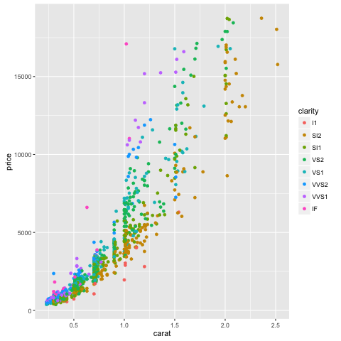

```python
%%R
library(ggplot2)
dsamp <- diamonds[sample(nrow(diamonds), 1000), ]
qplot(carat, price, data=dsamp, colour=clarity)
```

#### Embedding

The Notebook allows us to [embed iframes](http://ipython.org/ipython-doc/2/api/generated/IPython.lib.display.html). For example, from YouTube.

```python
from IPython.display import YouTubeVideo
```

```python
YouTubeVideo("p86BPM1GV8M")
```

[video not shown]

We can embed graphs. The plotly [ggplot2 figure](https://plot.ly/ggplot2/) converter lets us make the plot above into an interactive plot. Then you can call the plot in the NB.

```python
tls.embed('https://plot.ly/~MattSundquist/20391/price-vs-carat/')
```

[interactive chart not shown]

#### LaTeX

We can embed LaTeX inside a Notebook by putting a `$$` around our math, then run the cell as a Markdown cell. For example, the cell below is `$$c = \sqrt{a^2 + b^2}$$`, but the Notebook renders the expression.

$$c = \sqrt{a^2 + b^2}$$

Or, you can display output from Python, as seen [here](http://stackoverflow.com/questions/13208286/how-to-write-latex-in-ipython-notebook).

```python
from IPython.display import display, Math, Latex

display(Math(r'F(k) = \int_{-\infty}^{\infty} f(x) e^{2\pi i k} dx'))
```

$$F(k) = \int_{-\infty}^{\infty} f(x) e^{2\pi i k} dx$$

#### Publishing

We can export the Notebook as an HTML, PDF, .py, .ipynb, Markdown, and reST file. You can also turn your NB [into a slideshow](http://ipython.org/ipython-doc/2/notebook/nbconvert.html). For publishing IPython Notebooks directly to GitHub pages, you can use publisher. You can publish Notebooks on GitHub, and they will be generated as a Notebook on [nbviewer.ipython.org](http://nbviewer.ipython.org/). More advanced users can consider [using git for version control](http://stackoverflow.com/questions/18734739/using-ipython-notebooks-under-version-control).

[figure not shown]

#### IPython widgets

[IPython widgets](http://moderndata.plot.ly/widgets-in-ipython-notebook-and-plotly/) allow you to add sliders, widgets, search boxes, and more to your Notebook. See the [widget docs](https://ipython.org/ipython-doc/3/api/generated/IPython.html.widgets.interaction.html) for more information. For others to be able to access your work, they'll need IPython. Or, you can use a cloud-based NB option so others can run your work.

[figure not shown]

### Publishing Dash Apps

For users looking to ship and productionize Python apps, dash is an assemblage of Flask, Socketio, Jinja, Plotly and boiler plate CSS and JS for easily creating data visualization web-apps with your Python data analysis backend.

[figure not shown]

#### Publishing dashboards

Users publishing interactive graphs can also use [dashboards.ly](http://dashboards.ly/) to arrange a plot with a drag and drop interface. These dashboards can be published, embedded, and shared.

[figure not shown]

#### IPython gallery

For more IPython tutorials, see the [IPython gallery](https://plot.ly/ipython-notebooks/).

[figure not shown]

{% endraw %}